# Gliederung

### Modell1 nicht zentriert, reduziert

(in der Arbeit auf Seite 36)

```python
x_neu4= x_neu1.drop(["Arbeitsspeicher_quad", "Bild_Display", "extern_Schnittstellen", "SSD_quad", "Akku_Kapazität_quad", "PPI_Display_quad",  "Laufwerk_VORHANDEN", "Fingerabdrucksensor_vorhanden", "Mikrofon_Sound_vorhanden", "Rabatt_Lehreinrichtung_vorhanden", "Akku_Typ_ION","Marke_ASUS", "Marke_Acer", "Marke_Dell", "Betriebssystem_LINUX"], axis=1)
model = sm.OLS(y.Preis, x_neu4)
mod_lin2 = model.fit(cov_type="HC0")
x["fit_mod_lin2"] = mod_lin2.fittedvalues
x["resid_mod_lin2"] = mod_lin2.resid
print((y.Preis.corr(x.fit_mod_lin2))**2)
mod_lin2.summary()
```

```
0.8830120725397439
```

OLS Regression Results

| Dep. Variable: | Preis | R-squared: | 0.883 |
| --- | --- | --- | --- |
| Model: | OLS | Adj. R-squared: | 0.880 |
| Method: | Least Squares | F-statistic: | 442.5 |
| Date: | Sun, 20 Oct 2019 | Prob (F-statistic): | 0.00 |
| Time: | 18:11:31 | Log-Likelihood: | -7235.9 |
| No. Observations: | 1039 | AIC: | 1.452e+04 |
| Df Residuals: | 1013 | BIC: | 1.465e+04 |
| Df Model: | 25 |  |  |
| Covariance Type: | HC0 |  |  |

|  | coef | std err | z | P>\|z\| | [0.025 | 0.975] |
| --- | --- | --- | --- | --- | --- | --- |
| Kerne | -13.3780 | 36.420 | -0.367 | 0.713 | -84.759 | 58.003 |
| Kerne_quad | 12.6533 | 3.878 | 3.263 | 0.001 | 5.052 | 20.254 |
| Takt_Prozessor | -0.4657 | 0.234 | -1.987 | 0.047 | -0.925 | -0.006 |
| Takt_Prozessor_quad | 0.0001 | 5.63e-05 | 2.633 | 0.008 | 3.79e-05 | 0.000 |
| Arbeitsspeicher | 29.8923 | 2.293 | 13.038 | 0.000 | 25.399 | 34.386 |
| Bild_Display_quad | 0.2492 | 0.316 | 0.788 | 0.431 | -0.371 | 0.869 |
| Speicher_Grafik | 0.0831 | 0.018 | 4.551 | 0.000 | 0.047 | 0.119 |
| Speicher_Grafik_quad | -1.214e-05 | 3.86e-06 | -3.147 | 0.002 | -1.97e-05 | -4.58e-06 |
| HDD | 0.1698 | 0.047 | 3.631 | 0.000 | 0.078 | 0.262 |
| HDD_quad | -0.0002 | 2.96e-05 | -6.862 | 0.000 | -0.000 | -0.000 |
| SSD | 0.3329 | 0.045 | 7.393 | 0.000 | 0.245 | 0.421 |
| Akku_Kapazität | 12.8978 | 0.954 | 13.514 | 0.000 | 11.027 | 14.768 |
| PPI_Display | 1.7943 | 0.364 | 4.936 | 0.000 | 1.082 | 2.507 |
| Pixelshader | -0.4064 | 0.070 | -5.790 | 0.000 | -0.544 | -0.269 |
| Pixelshader_quad | 0.0002 | 3.13e-05 | 7.567 | 0.000 | 0.000 | 0.000 |
| Tastatur_Beleuchtung_vorhanden | 138.8726 | 19.067 | 7.283 | 0.000 | 101.502 | 176.243 |
| Touchscreen_vorhanden | 85.0864 | 26.352 | 3.229 | 0.001 | 33.437 | 136.736 |
| Mobilfunk_vorhanden | 341.1363 | 36.127 | 9.443 | 0.000 | 270.329 | 411.944 |
| NFC_vorhanden | 255.2760 | 50.111 | 5.094 | 0.000 | 157.061 | 353.491 |
| Marke_Apple | 515.2218 | 40.990 | 12.569 | 0.000 | 434.882 | 595.561 |
| Marke_Lenovo | 191.1857 | 23.038 | 8.299 | 0.000 | 146.032 | 236.339 |
| Betriebssystem_DOS | -215.8241 | 32.415 | -6.658 | 0.000 | -279.356 | -152.292 |
| Betriebssystem_OHNE_BETRIEBSSYSTEM | -242.0150 | 31.315 | -7.728 | 0.000 | -303.391 | -180.639 |
| Lautsprecher_ÜBERDURCHSCHN_LAUTSPRECHER | 140.5240 | 45.210 | 3.108 | 0.002 | 51.914 | 229.134 |
| Typ_Arbeitsspeicher_DDR_4 | -126.4133 | 35.542 | -3.557 | 0.000 | -196.073 | -56.753 |
| Konstante | -187.1016 | 284.946 | -0.657 | 0.511 | -745.586 | 371.383 |

| Omnibus: | 90.511 | Durbin-Watson: | 1.710 |
| --- | --- | --- | --- |
| Prob(Omnibus): | 0.000 | Jarque-Bera (JB): | 133.651 |
| Skew: | 0.658 | Prob(JB): | 9.51e-30 |
| Kurtosis: | 4.165 | Cond. No. | 6.30e+08 |

Warnings:  
[1] Standard Errors are heteroscedasticity robust (HC0)  
[2] The condition number is large, 6.3e+08. This might indicate that there are  
strong multicollinearity or other numerical problems.

**Übersicht Anzahl Laptops mit positivem Einfluss durch Merkmal:**

Prozentsatz Laptops die positiv beeinflusst werden durch Komponente (In der Arbeit auf Seite 28)

```python
# Kerne
print(len(x[x.Kerne>1])/len(x))
# Takt_Prozessor
print(len(x[x.Takt_Prozessor>3146])/len(x))
# Speicher_Grafik
print(len(x[x.Speicher_Grafik<6925])/len(x))
# HDD
print(len(x[x.HDD<836])/len(x))
# Pixelshader
print(len(x[x.Pixelshader>1714])/len(x))
```

```
1.0
0.0009624639076034649
0.9653512993262753
0.8113570741097209
0.06352261790182868
```

```python
bil_m  =x.Bild_Display.min()**2*0.249181
bil_me =x.Bild_Display.mean()**2*0.249181
ppi_m  =x.PPI_Display.min()*1.794331
ppi_me = x.PPI_Display.mean()*1.794331
(bil_me+ppi_me)-(bil_m+ppi_m)
```

```
139.23821594213842
```

```python
91.11882998171846*-0.406427+91.11882998171846**2*0.000237
```

```
-35.06542675397465
```

Einfluss Grafikkarte (In der Arbeit auf Seite 29)

```
0.20202020202020204
-53.16329984000001
```

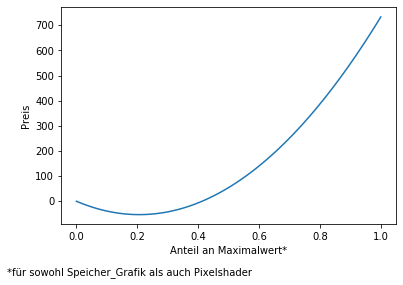

```python
p_max = x.Pixelshader.max()
s_max = x.Speicher_Grafik.max()

def pixel(wert):
    Pixel = wert*-0.406427+wert**2*0.000237
    return(Pixel)
def gr_speicher(wert):
    grspeicher = wert*0.083123+wert**2*-0.000012
    return(grspeicher)
def grafik(s1,p1):
    return(gr_speicher(s1)+pixel(p1))
def schätzungen_grafik(anzahl):
    x_achse = []
    y_achse = []
    for x in np.linspace(0,1,anzahl):
        s = s_max*x
        p = p_max*x
        x_achse.append(x)
        y_achse.append(grafik(s,p))
    plt.plot(x_achse,y_achse)
    plt.ylabel("Preis")
    plt.xlabel("Anteil an Maximalwert*")
    liste = [x for _,x in sorted(zip(y_achse,x_achse))][0]
    plt.figtext(0, -0.05, "*für sowohl Speicher_Grafik als auch Pixelshader", horizontalalignment='left')
    plt.savefig("grafikkarte_graph", bbox_inches = "tight")
    print(liste)
schätzungen_grafik(100)
print(grafik(s_max*0.2,p_max*0.2),)
```

```python
def einf_prz(zahl):
    Einfluss = (-13.377970*x[x.Kerne==zahl].Kerne+12.653288*x[x.Kerne==zahl].Kerne_quad-0.465746*
                x[x.Kerne==zahl].Takt_Prozessor+0.000148*x[x.Kerne==zahl].Takt_Prozessor_quad).mean()
    return(Einfluss)
Kerne2 = einf_prz(2)
Kerne4 = einf_prz(4)
Kerne6 = einf_prz(6)
Kerne8 = einf_prz(8)
print(x[x.Kerne>=6].Preis.mean())
print(Kerne4)
print(Kerne4-Kerne2)
print(Kerne6-Kerne4)
print(Kerne8-Kerne6)
print(Kerne8-Kerne2)
```

```
2185.9456962025315
-196.10027502571975
66.92373992463487
334.00904407835174
287.2538958045108
688.1866798074975
```

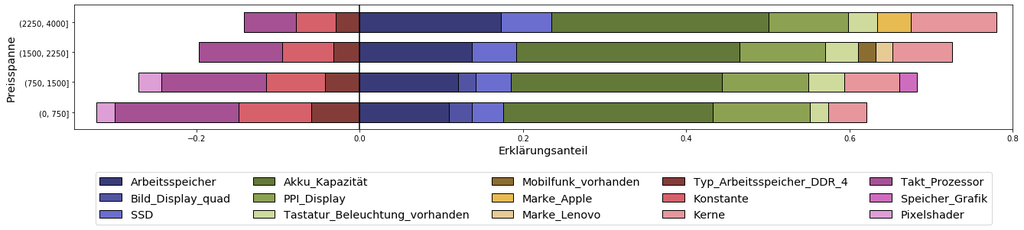

```python
gruppiert2 = übersicht(x.fit_mod_lin2, mod_lin2, -0.35, 0.8)
plt.savefig("modell1_nichtz_r", bbox_inches = "tight")
```

```python
gruppiert2
```

| Preisspanne | Arbeitsspeicher | Bild_Display_quad | SSD | Akku_Kapazität | PPI_Display | Tastatur_Beleuchtung_vorhanden | Mobilfunk_vorhanden | Marke_Apple | Marke_Lenovo | Typ_Arbeitsspeicher_DDR_4 | Konstante | Kerne | Takt_Prozessor | Speicher_Grafik | Pixelshader |
| --- | --- | --- | --- | --- | --- | --- | --- | --- | --- | --- | --- | --- | --- | --- | --- |
| (0, 750] | 0.109191 | 0.028149 | 0.038411 | 0.256775 | 0.118935 | 0.022055 | 0.000000 | 0.000000 | 0.000000 | -0.059274 | -0.089145 | 0.047314 | -0.151329 | 0.000000 | -0.022900 |
| (750, 1500] | 0.120118 | 0.021516 | 0.043874 | 0.258079 | 0.105862 | 0.044093 | 0.000000 | 0.000000 | 0.000000 | -0.042187 | -0.072342 | 0.067021 | -0.128516 | 0.022155 | -0.027822 |
| (1500, 2250] | 0.137352 | 0.000000 | 0.054650 | 0.272905 | 0.105089 | 0.040672 | 0.021647 | 0.000000 | 0.020531 | -0.032704 | -0.062408 | 0.072490 | -0.101910 | 0.000000 | 0.000000 |
| (2250, 4000] | 0.172433 | 0.000000 | 0.062529 | 0.265719 | 0.097498 | 0.035160 | 0.000000 | 0.041742 | 0.000000 | -0.029701 | -0.048887 | 0.104958 | -0.063443 | 0.000000 | 0.000000 |

```python
gruppiert2.mean().sort_values()
```

```
Takt_Prozessor    -0.111300
Konstante         -0.068196
                     ...
Arbeitsspeicher    0.134774
Akku_Kapazität     0.263369
Length: 15, dtype: float64
```

### Weitere Modelle die in der Arbeit nicht berücksichtigt wurden

Zurück zu Induktive Statistik

#### Ridge Regression

Die Ridge-Regression lieferte etwas bessere Ergebnisse als die OLS-Modelle

```
alpha: 0.005
Bestimmtheitsmaß für das Testset: 0.8938297993808044
```

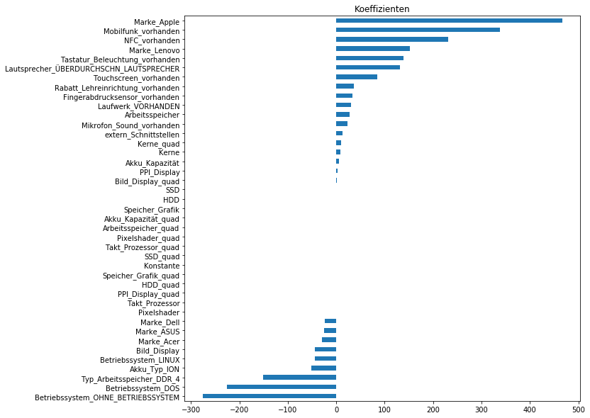

```python
from sklearn.linear_model import Ridge, RidgeCV, Lasso, LassoCV
from sklearn.metrics import mean_squared_error
from sklearn.model_selection import train_test_split
X_train, X_test , y_train, y_test = train_test_split(x_neu1, y.Preis, test_size=0.3, random_state=1)
alphas = 10**np.linspace(10,-2,100)*0.5
ridgecv = RidgeCV(alphas = alphas, scoring = 'neg_mean_squared_error', normalize = True)
ridgecv.fit(X_train, y_train)
ridgecv.alpha_
print("alpha:",ridgecv.alpha_)

ridge = Ridge(alpha = ridgecv.alpha_, normalize = True)
ridge.fit(X_test, y_test)
print("Bestimmtheitsmaß für das Testset:", ridge.score(X_test, y_test))

ridge.fit(x_neu1, y.Preis)
Koeffizienten = ridge.coef_
Koeffizienten_ridge = pd.Series(Koeffizienten, index = x_neu1.columns).sort_values()
plt.gcf().set_size_inches(10,10,forward=True)
Koeffizienten_ridge.plot(kind='barh', title='Koeffizienten');
```

### Hauptkomponentenanalyse

```python
# from sklearn.decomposition import PCA
# pca = PCA(n_components=5)
# principalComponents = pca.fit_transform(X)
# principalDf = pd.DataFrame(data = principalComponents)
```

### Regression der partiellen kleinsten Quadrate

```python
# from pandas import DataFrame
# from sklearn.cross_decomposition import PLSRegression

# def regPLS1(X_var,y_var):
#     _COMPS_ = len(X_var.columns) # all latent variables
#     model = PLSRegression(_COMPS_).fit( X_var, y_var )
#     return model.coef_
# regPLS1(X_log0,Log_Preis0)
```

```python
# from sklearn.cross_decomposition import PLSRegression
# from sklearn.metrics import mean_squared_error, r2_score
# from sklearn.model_selection import cross_val_predict

# pls = PLSRegression(n_components=10)

# # Fit
# pls.fit(X_log0,Log_Preis0)

# # Cross-validation
# y_cv = cross_val_predict(pls,X_log0,Log_Preis0, cv=10)

# # Calculate scores
# score = r2_score(Log_Preis0, y_cv)
# mse = mean_squared_error(Log_Preis0, y_cv)
# print(score)
```

```python
def parameter_einfl(modell_):
    parameter_einfluss = pd.DataFrame()
    modell = modell_
    basis0_koef = modell.params.to_frame(name="beta").reset_index().rename_axis(None).rename(columns={"index":"Merkmal"})
    for Merkmal in basis0_koef.Merkmal:
        try:
            Koeffizient = basis0_koef[basis0_koef.Merkmal == Merkmal].beta
            if ":" not in Merkmal:
                df = pd.DataFrame({"Merkmal":[Merkmal],
                            "Parameter": Koeffizient,"min. Wert:":x[Merkmal].min()*Koeffizient, "max. Wert":x[Merkmal].max()*Koeffizient})
                parameter_einfluss = parameter_einfluss.append(df)
            else:
                Merkmal = Merkmal.split(":")
                print(Merkmal[1])
                df = pd.DataFrame({"Merkmal":[Merkmal],
                            "Parameter": Koeffizient,"min. Wert:":x[Merkmal[0]].min()*x[Merkmal[1]].min()*Koeffizient, "max. Wert":x[Merkmal[0]].max()*x[Merkmal[1]].max()*Koeffizient})
                parameter_einfluss = parameter_einfluss.append(df)
        except KeyError: continue
        return(parameter_einfluss)
parameter_einfl(mod_lin0)
```

|  | Merkmal | Parameter | min. Wert: | max. Wert |
| --- | --- | --- | --- | --- |
| 0 | Kerne | -13.499252 | -26.998505 | -107.994019 |

```python
df_neu[df_neu.Touchscreen == "vorhanden"].Bild_Display.max()
```

```
17.3
```

### Verallgemeinerte Kleinste-Quadrate-Schätzung

```python
# x["log_u_dach_quad"]= np.log(basis_modell.resid**2)
# print(x.log_u_dach_quad.head(2))
# y, X = dmatrices("log_u_dach_quad ~ Takt_Prozessor+ Takt_Prozessor_quad+ Kerne_quad +\
#                  Arbeitsspeicher +\
#                  HDD + SSD + EMMC + HDD_quad + SSD_quad + EMMC_quad +\
#                  Akku_Kapazität_quad +\
#                  PPI_Display + PPI_Display_quad +\
#                  Bild_Display*Touchscreen_vorhanden+\
#                  Pixelshader + Pixelshader_quad +\
#                  Typ_Arbeitsspeicher_DDR_4+\
#                  Lautsprecher_ÜBERDURCHSCHN_LAUTSPRECHER + \
#                  Tastatur_Beleuchtung_vorhanden+\
#                  Fingerabdrucksensor_vorhanden+\
#                  Mobilfunk_vorhanden+\
#                  NFC_vorhanden+\
#                  Betriebssystem_DOS + Betriebssystem_OHNE_BETRIEBSSYSTEM+\
#                  Marke_ASUS + Marke_Acer + Marke_Apple + Marke_Dell + Marke_Lenovo" ,data=x, return_type='dataframe')
# model = sm.OLS(y, X)
# basis_modell_resid = model.fit()
# #basis_modell_resid.summary()
```

```python
# x["gewicht"] = 1/np.exp(basis_modell_resid.fittedvalues)
# y, X = dmatrices("Preis ~ Takt_Prozessor+ Takt_Prozessor_quad+ Kerne_quad +\
#                  Arbeitsspeicher +\
#                  HDD + SSD + EMMC + HDD_quad + SSD_quad + EMMC_quad +\
#                  Akku_Kapazität_quad +\
#                  PPI_Display + PPI_Display_quad +\
#                  Bild_Display*Touchscreen_vorhanden+\
#                  Pixelshader + Pixelshader_quad +\
#                  Typ_Arbeitsspeicher_DDR_4+\
#                  Lautsprecher_ÜBERDURCHSCHN_LAUTSPRECHER + \
#                  Tastatur_Beleuchtung_vorhanden+\
#                  Fingerabdrucksensor_vorhanden+\
#                  Mobilfunk_vorhanden+\
#                  NFC_vorhanden+\
#                  Betriebssystem_DOS + Betriebssystem_OHNE_BETRIEBSSYSTEM+\
#                  Marke_ASUS + Marke_Acer + Marke_Apple + Marke_Dell + Marke_Lenovo" ,data=x, return_type='dataframe')
# model = sm.WLS(y, X, weights=x["gewicht"])
# basis_modell_wls = model.fit()
# basis_modell_wls.summary()
```

```python
# df_neu["fit1"] = basis_modell_wls.fittedvalues
# df_neu["resid1"] = basis_modell_wls.resid
# plt.scatter(df_neu.fit_mod_lin0, df_neu.fit_mod_lin0, edgecolor="black", label="OLS")
# plt.scatter(df_neu.fit1, df_neu.resid1, edgecolor="black", alpha=0.7, label="WLS")
# plt.legend()
# plt.title("Prognosewerte für den Preis und zugehörige Residuen")
# plt.xlabel("Prognose in Euro")
# plt.ylabel("Residuum")
# plt.savefig("residuen_ols_wls");
```

## Das aktuelle Sortiment

Zurück zur Gliederung

Um zu überprüfen, ob die Schätzer die Preise des neuen Sortiments noch gut beschreiben können, wurden erneut alle Daten der Laptops aus den entspreichenden Seiten geparsed. Der Datensatz wurde am 29.09 erstellt, also rund eineinhalb Monate nach dem erstellen des ersten Datensatzes. Die Vorgehensweise war dabei identisch. Nur eine Rubrik wurde umbenannt (Speicher in Datenspeicher). Auch die weiteren Schritte entsprachen weitestgehend der oben abgebildeten Vorgehensweise.

```python
df = pd.read_csv('edited_laptops_neu.csv', encoding='cp1252')
```

die Merkmale werden umbenannt

```python
df.columns = df.columns.str.replace("-", "_")
df = df.rename(columns={"Bezeichnung_Prozessor":"Prozessor",
                        "Anzahl_Prozessorkerne_Prozessor":"Kerne",
                        "Taktfrequenz_Prozessor": "Takt_Prozessor",
                        "Gesamt_Kapazität_Arbeitsspeicher": "Arbeitsspeicher",
                        "Anzahl Objektive_Rückseite_Kamera": "Kameras_Rückseite",
                        "SSD_Kapazität":"SSD",
                        "HDD_Kapazität":"HDD",
                        "EMMC_Kapazität":"EMMC",
                        "EMMC_Kapazität_sq": "EMMC_quad",
                        "HDD_Kapazität_sq": "HDD_quad",
                        "SSD_Kapazität_sq": "SSD_quad",
                        "Typ_Optisches Laufwerk": "Laufwerk",
                        "Gesamt_Speicher_Grafik": "Speicher_Grafik",
                        "Lautsprecher_Sound":"Lautsprecher",
                        "Layout_Tastatur_Eingabe": "Tastatur_Layout",
                        "Fingerabdrucksensor_Eingabe": "Fingerabdrucksensor",
                        "Touchscreen_Eingabe": "Touchscreen",
                        "Mobilefunk Standards_Konnektivität": "Mobilfunk",
                        "NFC_Konnektivität": "NFC",})
```

Übersicht des aktuellen Datensatzes:

```python
df
```

|  | Laptop_ID | Preis | Prozessor | Kerne | Takt_Prozessor | Arbeitsspeicher | Typ_Arbeitsspeicher | Bild_Display | Auflösung_Display | Typ_Grafik | Anzahl_Datenspeicher | Laufwerk | Lautsprecher | Mikrofon_Sound | Betriebssystem | extern_Schnittstellen | vorhanden_Zubehör | URL | Tastatur_Beleuchtung | Fingerabdrucksensor | Touchscreen | Mobilfunk | NFC | Speicher_Grafik | HDD | HDD_Anzahl | HDD_quad | SSD | SSD_Anzahl | … |
| --- | --- | --- | --- | --- | --- | --- | --- | --- | --- | --- | --- | --- | --- | --- | --- | --- | --- | --- | --- | --- | --- | --- | --- | --- | --- | --- | --- | --- | --- | --- |
| 0 | 4 | 579.00 | Intel® Core™ i5-8265U | 4 | 1600 | 8 | DDR 4 | 15.6 | 1.366 x 768 Pixel | Intel UHD Graphics 620 | 1 | nicht vorhanden | STANDARD LAUTSPRECHER | vorhanden | WINDOWS | 6 | vorhanden | https://www.alternate.de/Acer/Aspire-3-(A315-54-51ZQ)-Notebook/html/product/1539695? | nicht vorhanden | nicht vorhanden | nicht vorhanden | nicht vorhanden | nicht vorhanden | 0 | 0 | 0 | 0 | 256 | 1 | … |
| 1 | 11 | 1040.95 | Intel® Core™ i7-8565U | 4 | 1800 | 8 | DDR 4 | 14.0 | 1.920 x 1.080 Pixel | NVIDIA GeForce MX250 | 1 | nicht vorhanden | STANDARD LAUTSPRECHER | vorhanden | WINDOWS | 5 | vorhanden | https://www.alternate.de/Acer/Swift-3-(SF314-55G-768V)-Notebook/html/product/1522897? | vorhanden | vorhanden | nicht vorhanden | nicht vorhanden | nicht vorhanden | 2048 | 0 | 0 | 0 | 512 | 1 | … |
| ... | ... | ... | ... | ... | ... | ... | ... | ... | ... | ... | ... | ... | ... | ... | ... | ... | ... | ... | ... | ... | ... | ... | ... | ... | ... | ... | ... | ... | ... | … |
| 1458 | 1738 | 2729.00 | Intel® Core™ i7 | 6 | 2600 | 16 | DDR 4 | 15.4 | 2.880 x 1.800 Pixel | AMD Radeon Pro 560X | 1 | nicht vorhanden | STANDARD LAUTSPRECHER | vorhanden | MAC | 5 | vorhanden | https://www.alternate.de/Apple/MacBook-Pro-39-1-cm-(15-4-Zoll)-2019-CTO-Notebook/html/product/1567377? | vorhanden | vorhanden | nicht vorhanden | nicht vorhanden | nicht vorhanden | 4096 | 0 | 0 | 0 | 512 | 1 | … |
| 1459 | 1740 | 4279.00 | Intel® Core™ i9 | 8 | 2300 | 32 | DDR 4 | 15.4 | 2.880 x 1.800 Pixel | AMD Radeon Pro Vega 20 | 1 | nicht vorhanden | STANDARD LAUTSPRECHER | vorhanden | MAC | 5 | vorhanden | https://www.alternate.de/Apple/MacBook-Pro-39-1-cm-(15-4-Zoll)-2019-Notebook/html/product/1568367? | vorhanden | vorhanden | nicht vorhanden | nicht vorhanden | nicht vorhanden | 4096 | 0 | 0 | 0 | 2048 | 1 | … |

1460 rows × 42 columns

```python
df_anzahl = df.count().rename_axis('Merkmale').reset_index(name='Anzahl').sort_values(["Anzahl"], ascending=False)
df_anzahl.tail(8)
```

|  | Merkmale | Anzahl |
| --- | --- | --- |
| 14 | Betriebssystem | 1460 |
| 15 | extern_Schnittstellen | 1460 |
| ... | ... | ... |
| 34 | Akku_Kapazität | 1332 |
| 41 | benötigt_Zubehör | 1 |

8 rows × 2 columns

**Die Observation mit der Ausprägung bei benötigt_Zubehör wird gelöscht:**

```python
indexNames = df[df["benötigt_Zubehör"] == "Tastatur" ].index
df.drop(indexNames , inplace=True)
df = df.drop(columns="benötigt_Zubehör")
```

Anzahl an Merkmalen:

```python
len(df.columns)
```

```
41
```

### gekürzte Kopie des berarbeiteten Datensets, ohne fehlende Werte

Anzahl an Observationen, wenn fehlende Merkmale ausgeschlossen werden:

```python
df_neu = df.dropna()
len(df_neu)
df_neu.set_index("Laptop_ID", inplace=True)
```

Anzahl an Observationen, wenn Duplikate ausgeschlossen werden:

```python
exogene_var = list(set(df_neu.columns) - set(["Laptop_ID", "Preis", "URL"]))
df_neu_exogen = df_neu[exogene_var]
```

```python
df_neu_exogen.drop_duplicates()
len(df_neu_exogen)
```

```
1262
```

Es sind also keine Duplikate im Datenset

Alle Merkmale haben dieselbe Anzahl

```python
df_anzahl_neu = df_neu.count().rename_axis('Merkmale').reset_index(name='Anzahl').sort_values(["Anzahl"], ascending=False)
df_anzahl_neu
```

|  | Merkmale | Anzahl |
| --- | --- | --- |
| 0 | Preis | 1262 |
| 1 | Prozessor | 1262 |
| ... | ... | ... |
| 17 | Tastatur_Beleuchtung | 1262 |
| 39 | Pixelshader | 1262 |

40 rows × 2 columns

### Löschen einiger Merkmale und Merkmalsausprägungen

Typ-Grafik und Modell entsprechen einander. Diese vier Merkmale sind die Einzigen, die nicht als Dummy-Variablen dargestellt werden sollen und jeweils andere Merkmale haben, die den Zusammenhang zu dem entsprechenden Preis besser erkären und werden deshalb gelöscht

```python
pd.set_option('display.max_colwidth', -1)
df_neu[["Prozessor", "Auflösung_Display", "Typ_Grafik", "Modell", "URL"]].head(4)
```

| Laptop_ID | Prozessor | Auflösung_Display | Typ_Grafik | Modell | URL |
| --- | --- | --- | --- | --- | --- |
| 4 | Intel® Core™ i5-8265U | 1.366 x 768 Pixel | Intel UHD Graphics 620 | Intel UHD Graphics 620 | https://www.alternate.de/Acer/Aspire-3-(A315-54-51ZQ)-Notebook/html/product/1539695? |
| 11 | Intel® Core™ i7-8565U | 1.920 x 1.080 Pixel | NVIDIA GeForce MX250 | NVIDIA GeForce MX250 | https://www.alternate.de/Acer/Swift-3-(SF314-55G-768V)-Notebook/html/product/1522897? |
| 14 | Intel® Core™ i7-8550U | 1.920 x 1.080 Pixel | Intel UHD Graphics 620 | Intel UHD Graphics 620 | https://www.alternate.de/HP/Probook-650-G4-(3UP60EA)-Notebook/html/product/1500171? |
| 22 | Intel® Core™ i7-8665U | 2.560 x 1.440 Pixel | NVIDIA Quadro P520 | NVIDIA Quadro P520 | https://www.alternate.de/Lenovo/ThinkPad-P43s-(20RH001CGE)-Notebook/html/product/1568672? |

```python
df_neu = df_neu.drop(["Prozessor", "Auflösung_Display", "Typ_Grafik", "Modell"], axis = 1)
```

Das gekürzte Datenset besteht nur aus neuen Laptops, das Merkmal Zustand wird deshalb ebenfalls gelöscht

```python
print("Zustand:\n", df_neu.Zustand.value_counts())
df_neu = df_neu.drop("Zustand", axis= 1);
```

```
Zustand:
 neu    1262
Name: Zustand, dtype: int64
```

die Anzahl der Datenspeicher setzt sich aus der Summe von Anzahl an SSDs und HDDs zusammen. Da ein grundlegender Unterschied zwischen diesen beiden Festplattentypen sollte, wird dieses Merkmal ebenfalls gelöscht

```python
df_neu[["Anzahl_Datenspeicher", "HDD_Anzahl", "SSD_Anzahl", "EMMC_Anzahl"]].head(5)
```

| Laptop_ID | Anzahl_Datenspeicher | HDD_Anzahl | SSD_Anzahl | EMMC_Anzahl |
| --- | --- | --- | --- | --- |
| 4 | 1 | 0 | 1 | 0 |
| 11 | 1 | 0 | 1 | 0 |
| 14 | 1 | 0 | 1 | 0 |
| 22 | 1 | 0 | 1 | 0 |
| 26 | 1 | 0 | 1 | 0 |

```python
df_neu = df_neu.drop("Anzahl_Datenspeicher", axis=1);
```

Einzelne Marken sind selten vertreten im Datenset und werden ebenfalls gelöscht

```python
Anzahl_Marke = df_neu.groupby(["Marke"], as_index=False).size().to_frame("Anzahl").reset_index(level=0)
Liste = Anzahl_Marke[Anzahl_Marke.Anzahl < 44]
for Markealt in Liste.Marke:
    print("Laptops mit der Marke",Markealt, "werden gelöscht")
    df_neu = df_neu[df_neu["Marke"] != Markealt]
```

```
Laptops mit der Marke ALTERNATE werden gelöscht
Laptops mit der Marke AORUS werden gelöscht
Laptops mit der Marke Alienware werden gelöscht
Laptops mit der Marke Fujitsu werden gelöscht
Laptops mit der Marke GIGABYTE werden gelöscht
Laptops mit der Marke MSI werden gelöscht
Laptops mit der Marke Razer werden gelöscht
Laptops mit der Marke Schenker werden gelöscht
Laptops mit der Marke TrekStor werden gelöscht
Laptops mit der Marke XMG werden gelöscht
```

```python
len(df_neu)
```

```
1084
```

Laptops die eine eMMC Speicherkarte haben, werden gelöscht:

```python
df_neu = df_neu[df_neu.EMMC == 0]
del df_neu["EMMC"]
del df_neu["EMMC_Anzahl"]
del df_neu["EMMC_quad"]
```

Auch die quadratischen Terme von HDD und SSD werden gelöscht, da sich diese auf die Einzelwerte und nicht wie im ursprünglichen Datensatz auf die Summe der Einzelwerte bezieht. Beispiel: SSD_quad für die Einzelwerte 1000 GB und 256 GB ist hier 1000^2+256^2 und nicht 1256^2

```python
del df_neu["HDD_quad"]
del df_neu["SSD_quad"]
```

**Löschen von Laptops mit einem Preis von über 4000 Euro:**

```python
df_neu = df_neu[df_neu.Preis<=4000]
```

#### Die Laptops sind etwas teurer geworden:

```python
df_neu.Preis.mean()
```

```
1412.3689092664092
```

### Der Ausreißer ist noch im Sortiment und wird wieder gelöscht

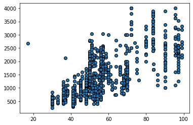

```python
plt.scatter(df_neu.Akku_Kapazität,df_neu.Preis, edgecolor="black")
```

```python
df_neu = df_neu[df_neu.Akku_Kapazität > 20]
```

### qualitative Merkmale

```python
df_neu[["Typ_Arbeitsspeicher", "Laufwerk", "Lautsprecher", "Tastatur_Beleuchtung", "Betriebssystem",
        "Fingerabdrucksensor", "Touchscreen", "Rabatt_Lehreinrichtung"]].head(2)
```

| Laptop_ID | Typ_Arbeitsspeicher | Laufwerk | Lautsprecher | Tastatur_Beleuchtung | Betriebssystem | Fingerabdrucksensor | Touchscreen | Rabatt_Lehreinrichtung |
| --- | --- | --- | --- | --- | --- | --- | --- | --- |
| 4 | DDR 4 | nicht vorhanden | STANDARD LAUTSPRECHER | nicht vorhanden | WINDOWS | nicht vorhanden | nicht vorhanden | nicht vorhanden |
| 11 | DDR 4 | nicht vorhanden | STANDARD LAUTSPRECHER | vorhanden | WINDOWS | vorhanden | nicht vorhanden | nicht vorhanden |

```python
for Merkmal in df_neu[["Typ_Arbeitsspeicher", "Laufwerk", "Lautsprecher", "Tastatur_Beleuchtung",
                     "Fingerabdrucksensor", "Touchscreen", "Mobilfunk", "NFC",
                     "Akku_Typ", "Marke", "Betriebssystem", "Mikrofon_Sound", "Rabatt_Lehreinrichtung"]]:
    print(Merkmal.ljust(30,"-"), df_neu[Merkmal].unique())
```

```
Typ_Arbeitsspeicher----------- ['DDR 4' 'DDR 3']
Laufwerk---------------------- ['nicht vorhanden' 'VORHANDEN' 'Extern CD/DVD']
Lautsprecher------------------ ['STANDARD LAUTSPRECHER' 'ÜBERDURCHSCHN LAUTSPRECHER']
Tastatur_Beleuchtung---------- ['nicht vorhanden' 'vorhanden']
Fingerabdrucksensor----------- ['nicht vorhanden' 'vorhanden']
Touchscreen------------------- ['nicht vorhanden' 'vorhanden']
Mobilfunk--------------------- ['nicht vorhanden' 'vorhanden']
NFC--------------------------- ['nicht vorhanden' 'vorhanden']
Akku_Typ---------------------- ['ION' 'POLYMER']
Marke------------------------- ['Acer' 'HP' 'Lenovo' 'Dell' 'ASUS' 'Apple']
Betriebssystem---------------- ['WINDOWS' 'OHNE BETRIEBSSYSTEM' 'LINUX' 'MAC' 'DOS' '-']
Mikrofon_Sound---------------- ['vorhanden' 'nicht vorhanden']
Rabatt_Lehreinrichtung-------- ['nicht vorhanden' 'vorhanden']
```

Die Ausprägungen der qualitativen Merkmale sind identisch, lediglich in ezwei Fällen (Laufwerk und Betriebssystem) ergab sich ein neuer Wert. Die Observationen mit "Extern CD/DVD" und "-" werden deshalb gelöscht

```python
df_neu = df_neu[df_neu.Betriebssystem != "-"]
df_neu = df_neu[df_neu.Laufwerk != "Extern CD/DVD"]
```

```python
binäre_variablen = pd.get_dummies(df_neu[["Rabatt_Lehreinrichtung","Typ_Arbeitsspeicher", "Laufwerk", "Lautsprecher", "Tastatur_Beleuchtung",
                     "Fingerabdrucksensor", "Touchscreen", "Mobilfunk", "NFC",
                     "Akku_Typ", "Marke", "Betriebssystem", "Mikrofon_Sound"]])
```

```python
Merkmale = binäre_variablen.columns.tolist()
Merkmale = Merkmale[-1:] + Merkmale[:-1]
binäre_variablen = binäre_variablen[Merkmale]
```

```python
for Merkmal in Merkmale:
    binäre_variablen.columns = binäre_variablen.columns.str.replace(" ", "_")
del Merkmale
binäre_variablen.head(2)
```

| Laptop_ID | Mikrofon_Sound_vorhanden | Rabatt_Lehreinrichtung_nicht_vorhanden | Rabatt_Lehreinrichtung_vorhanden | Typ_Arbeitsspeicher_DDR_3 | Typ_Arbeitsspeicher_DDR_4 | Laufwerk_VORHANDEN | Laufwerk_nicht_vorhanden | Lautsprecher_STANDARD_LAUTSPRECHER | Lautsprecher_ÜBERDURCHSCHN_LAUTSPRECHER | Tastatur_Beleuchtung_nicht_vorhanden | Tastatur_Beleuchtung_vorhanden | Fingerabdrucksensor_nicht_vorhanden | Fingerabdrucksensor_vorhanden | Touchscreen_nicht_vorhanden | Touchscreen_vorhanden | Mobilfunk_nicht_vorhanden | Mobilfunk_vorhanden | NFC_nicht_vorhanden | NFC_vorhanden | Akku_Typ_ION | Akku_Typ_POLYMER | Marke_ASUS | Marke_Acer | Marke_Apple | Marke_Dell | Marke_HP | Marke_Lenovo | Betriebssystem_DOS | Betriebssystem_LINUX | … |
| --- | --- | --- | --- | --- | --- | --- | --- | --- | --- | --- | --- | --- | --- | --- | --- | --- | --- | --- | --- | --- | --- | --- | --- | --- | --- | --- | --- | --- | --- | --- |
| 4 | 1 | 1 | 0 | 0 | 1 | 0 | 1 | 1 | 0 | 1 | 0 | 1 | 0 | 1 | 0 | 1 | 0 | 1 | 0 | 1 | 0 | 0 | 1 | 0 | 0 | 0 | 0 | 0 | 0 | … |
| 11 | 1 | 1 | 0 | 0 | 1 | 0 | 1 | 1 | 0 | 0 | 1 | 0 | 1 | 1 | 0 | 1 | 0 | 1 | 0 | 1 | 0 | 0 | 1 | 0 | 0 | 0 | 0 | 0 | 0 | … |

```python
binäre_variablen = binäre_variablen.drop(["Typ_Arbeitsspeicher_DDR_3", "Laufwerk_nicht_vorhanden",
                        "Lautsprecher_STANDARD_LAUTSPRECHER", "Tastatur_Beleuchtung_nicht_vorhanden",
                      "Fingerabdrucksensor_nicht_vorhanden", "Touchscreen_nicht_vorhanden",
                      "Mobilfunk_nicht_vorhanden", "NFC_nicht_vorhanden", "Betriebssystem_WINDOWS", "Betriebssystem_MAC",
                      "Akku_Typ_POLYMER", "Marke_HP",
                        "Mikrofon_Sound_nicht_vorhanden", "Rabatt_Lehreinrichtung_nicht_vorhanden"], axis=1)
```

### Quantitative Merkmale

Anmerkung: Der Preis ist hier in den quantiativen Merkmalen enthalten

```python
quantitative_variablen = df_neu.drop(["Typ_Arbeitsspeicher", "Laufwerk", "Lautsprecher", "Tastatur_Beleuchtung",
                      "Fingerabdrucksensor", "Touchscreen", "Mobilfunk", "NFC","vorhanden_Zubehör",
                      "Akku_Typ", "Betriebssystem", "Mikrofon_Sound", "Rabatt_Lehreinrichtung",
                    "HDD_Anzahl", "SSD_Anzahl", "Marke"], axis=1)
```

### Zusammenfügen qualitativer und quantitativer Merkmale

```python
len(binäre_variablen)
```

```
1031
```

```python
x = pd.concat([quantitative_variablen, binäre_variablen], axis="columns")
```

```python
for Marke in df_neu.Marke.unique().tolist():
    print("Durchschnittlicher Preis für die Marke", Marke, ":", df_neu[df_neu.Marke == Marke].Preis.mean())
```

```
Durchschnittlicher Preis für die Marke Acer : 1111.4503448275862
Durchschnittlicher Preis für die Marke HP : 1330.8710263157895
Durchschnittlicher Preis für die Marke Lenovo : 1461.3881516587678
Durchschnittlicher Preis für die Marke Dell : 1496.5694444444443
Durchschnittlicher Preis für die Marke ASUS : 1066.125
Durchschnittlicher Preis für die Marke Apple : 2517.7323943661972
```

### Laden der alten Daten

```python
df_alt = pd.read_csv(r'C:\Users\tobia\Desktop\Uni\Marburg\Bachelorarbeit\Alternate\fertiges_datenset.csv')
df_alt.set_index("Laptop_ID", inplace=True)
```

```python
len(df_alt)
```

```
1039
```

```python
def xyz():
    überprüfen1 = set(x.URL)-set(df_alt.URL)
    print(len(überprüfen1))
    return(x[x['URL'].isin(list(überprüfen1))])
x = xyz().drop("URL", axis=1)
```

```
236
```

```python
x.head(2)
```

| Laptop_ID | Preis | Kerne | Takt_Prozessor | Arbeitsspeicher | Bild_Display | extern_Schnittstellen | Speicher_Grafik | HDD | SSD | Akku_Kapazität | PPI_Display | Pixelshader | Mikrofon_Sound_vorhanden | Rabatt_Lehreinrichtung_vorhanden | Typ_Arbeitsspeicher_DDR_4 | Laufwerk_VORHANDEN | Lautsprecher_ÜBERDURCHSCHN_LAUTSPRECHER | Tastatur_Beleuchtung_vorhanden | Fingerabdrucksensor_vorhanden | Touchscreen_vorhanden | Mobilfunk_vorhanden | NFC_vorhanden | Akku_Typ_ION | Marke_ASUS | Marke_Acer | Marke_Apple | Marke_Dell | Marke_Lenovo | Betriebssystem_DOS | … |
| --- | --- | --- | --- | --- | --- | --- | --- | --- | --- | --- | --- | --- | --- | --- | --- | --- | --- | --- | --- | --- | --- | --- | --- | --- | --- | --- | --- | --- | --- | --- |
| 31 | 849.0 | 4 | 1800 | 8 | 15.6 | 6 | 2048 | 1000 | 128 | 45.0 | 141 | 384.0 | 1 | 0 | 1 | 0 | 0 | 0 | 0 | 0 | 0 | 0 | 1 | 0 | 0 | 0 | 0 | 0 | 0 | … |
| 91 | 2099.0 | 2 | 2800 | 8 | 13.3 | 4 | 0 | 0 | 256 | 57.0 | 165 | 24.0 | 1 | 0 | 1 | 0 | 0 | 1 | 1 | 1 | 0 | 0 | 1 | 0 | 0 | 0 | 0 | 0 | 0 | … |

```python
x = x[["Preis", 'Kerne', 'Takt_Prozessor', 'Arbeitsspeicher', 'Bild_Display','Speicher_Grafik',
       'extern_Schnittstellen', 'HDD', 'SSD',
       "Akku_Kapazität", 'PPI_Display', 'Pixelshader',
       'Typ_Arbeitsspeicher_DDR_4', 'Laufwerk_VORHANDEN',
       'Lautsprecher_ÜBERDURCHSCHN_LAUTSPRECHER',
       'Tastatur_Beleuchtung_vorhanden', 'Fingerabdrucksensor_vorhanden',
       'Touchscreen_vorhanden', 'Mobilfunk_vorhanden', 'NFC_vorhanden',
       'Akku_Typ_ION', 'Marke_ASUS', 'Marke_Acer', 'Marke_Apple', 'Marke_Dell',
       'Marke_Lenovo', 'Betriebssystem_DOS', 'Betriebssystem_LINUX',
       'Betriebssystem_OHNE_BETRIEBSSYSTEM',
       'Mikrofon_Sound_vorhanden', 'Rabatt_Lehreinrichtung_vorhanden',]]
```

```python
x.head(2)
```

| Laptop_ID | Preis | Kerne | Takt_Prozessor | Arbeitsspeicher | Bild_Display | Speicher_Grafik | extern_Schnittstellen | HDD | SSD | Akku_Kapazität | PPI_Display | Pixelshader | Typ_Arbeitsspeicher_DDR_4 | Laufwerk_VORHANDEN | Lautsprecher_ÜBERDURCHSCHN_LAUTSPRECHER | Tastatur_Beleuchtung_vorhanden | Fingerabdrucksensor_vorhanden | Touchscreen_vorhanden | Mobilfunk_vorhanden | NFC_vorhanden | Akku_Typ_ION | Marke_ASUS | Marke_Acer | Marke_Apple | Marke_Dell | Marke_Lenovo | Betriebssystem_DOS | Betriebssystem_LINUX | Betriebssystem_OHNE_BETRIEBSSYSTEM | … |
| --- | --- | --- | --- | --- | --- | --- | --- | --- | --- | --- | --- | --- | --- | --- | --- | --- | --- | --- | --- | --- | --- | --- | --- | --- | --- | --- | --- | --- | --- | --- |
| 31 | 849.0 | 4 | 1800 | 8 | 15.6 | 2048 | 6 | 1000 | 128 | 45.0 | 141 | 384.0 | 1 | 0 | 0 | 0 | 0 | 0 | 0 | 0 | 1 | 0 | 0 | 0 | 0 | 0 | 0 | 0 | 0 | … |
| 91 | 2099.0 | 2 | 2800 | 8 | 13.3 | 0 | 4 | 0 | 256 | 57.0 | 165 | 24.0 | 1 | 0 | 0 | 1 | 1 | 1 | 0 | 0 | 1 | 0 | 0 | 0 | 0 | 0 | 0 | 0 | 0 | … |

```python
df_alt = df_alt.drop("URL", axis=1)
df_alt.head(2)
```

| Laptop_ID | Preis | Kerne | Takt_Prozessor | Arbeitsspeicher | Bild_Display | Speicher_Grafik | extern_Schnittstellen | HDD | SSD | Akku_Kapazität | PPI_Display | Pixelshader | Typ_Arbeitsspeicher_DDR_4 | Laufwerk_VORHANDEN | Lautsprecher_ÜBERDURCHSCHN_LAUTSPRECHER | Tastatur_Beleuchtung_vorhanden | Fingerabdrucksensor_vorhanden | Touchscreen_vorhanden | Mobilfunk_vorhanden | NFC_vorhanden | Akku_Typ_ION | Marke_ASUS | Marke_Acer | Marke_Apple | Marke_Dell | Marke_Lenovo | Betriebssystem_DOS | Betriebssystem_LINUX | Betriebssystem_OHNE_BETRIEBSSYSTEM | … |
| --- | --- | --- | --- | --- | --- | --- | --- | --- | --- | --- | --- | --- | --- | --- | --- | --- | --- | --- | --- | --- | --- | --- | --- | --- | --- | --- | --- | --- | --- | --- |
| 2 | 299.0 | 2 | 2600 | 8 | 15.6 | 0 | 6 | 0 | 256 | 41.0 | 141 | 192.0 | 1 | 1 | 0 | 0 | 0 | 0 | 0 | 0 | 1 | 0 | 0 | 0 | 0 | 0 | 0 | 0 | 1 | … |
| 4 | 899.0 | 6 | 2200 | 8 | 15.6 | 6144 | 9 | 1000 | 128 | 70.0 | 141 | 1280.0 | 1 | 0 | 0 | 1 | 0 | 0 | 0 | 0 | 1 | 0 | 0 | 0 | 0 | 0 | 0 | 0 | 0 | … |

```python
x[~x.isin(df_alt)].dropna()
```

| Laptop_ID | Preis | Kerne | Takt_Prozessor | Arbeitsspeicher | Bild_Display | Speicher_Grafik | extern_Schnittstellen | HDD | SSD | Akku_Kapazität | PPI_Display | Pixelshader | Typ_Arbeitsspeicher_DDR_4 | Laufwerk_VORHANDEN | Lautsprecher_ÜBERDURCHSCHN_LAUTSPRECHER | Tastatur_Beleuchtung_vorhanden | Fingerabdrucksensor_vorhanden | Touchscreen_vorhanden | Mobilfunk_vorhanden | NFC_vorhanden | Akku_Typ_ION | Marke_ASUS | Marke_Acer | Marke_Apple | Marke_Dell | Marke_Lenovo | Betriebssystem_DOS | Betriebssystem_LINUX | Betriebssystem_OHNE_BETRIEBSSYSTEM | … |
| --- | --- | --- | --- | --- | --- | --- | --- | --- | --- | --- | --- | --- | --- | --- | --- | --- | --- | --- | --- | --- | --- | --- | --- | --- | --- | --- | --- | --- | --- | --- |
| 31 | 849.0 | 4.0 | 1800.0 | 8.0 | 15.6 | 2048.0 | 6.0 | 1000.0 | 128.0 | 45.0 | 141.0 | 384.0 | 1.0 | 0.0 | 0.0 | 0.0 | 0.0 | 0.0 | 0.0 | 0.0 | 1.0 | 0.0 | 0.0 | 0.0 | 0.0 | 0.0 | 0.0 | 0.0 | 0.0 | … |
| 232 | 1449.0 | 4.0 | 1800.0 | 16.0 | 13.3 | 0.0 | 6.0 | 0.0 | 512.0 | 53.0 | 165.0 | 24.0 | 1.0 | 0.0 | 0.0 | 1.0 | 1.0 | 1.0 | 0.0 | 0.0 | 1.0 | 0.0 | 0.0 | 0.0 | 0.0 | 0.0 | 0.0 | 0.0 | 1.0 | … |
| ... | ... | ... | ... | ... | ... | ... | ... | ... | ... | ... | ... | ... | ... | ... | ... | ... | ... | ... | ... | ... | ... | ... | ... | ... | ... | ... | ... | ... | ... | … |
| 1716 | 949.0 | 4.0 | 1600.0 | 8.0 | 14.0 | 0.0 | 9.0 | 0.0 | 256.0 | 61.9 | 157.0 | 24.0 | 1.0 | 0.0 | 0.0 | 1.0 | 1.0 | 0.0 | 0.0 | 0.0 | 1.0 | 0.0 | 1.0 | 0.0 | 0.0 | 0.0 | 0.0 | 0.0 | 0.0 | … |
| 1728 | 999.0 | 4.0 | 1800.0 | 16.0 | 14.0 | 2048.0 | 5.0 | 0.0 | 512.0 | 41.0 | 157.0 | 384.0 | 1.0 | 0.0 | 0.0 | 1.0 | 0.0 | 1.0 | 0.0 | 0.0 | 1.0 | 0.0 | 0.0 | 0.0 | 0.0 | 0.0 | 0.0 | 0.0 | 0.0 | … |

103 rows × 31 columns

```python
del df_alt
len(x)
```

```
236
```

#### erstellen quadratischer Werte und der Konstante

```python
x["Konstante"] = 1
x["Kerne_quad"] = x.Kerne**2
x["Takt_Prozessor_quad"] = x.Takt_Prozessor**2
x["Arbeitsspeicher_quad"] = x.Arbeitsspeicher**2
x["Bild_Display_quad"] = x.Bild_Display**2
x["Speicher_Grafik_quad"] = x.Speicher_Grafik**2
x["extern_Schnittstellen_quad"] = x.extern_Schnittstellen**2
x["HDD_quad"] = x.HDD**2
x["SSD_quad"] = x.SSD**2
x["Akku_Kapazität_quad"] = x.Akku_Kapazität**2
x["PPI_Display_quad"] =x.PPI_Display**2
x["Pixelshader_quad"] =x.Pixelshader**2
```

```python
x_Modell1_neu = x[x_neu4.columns]
mod_lin2_neu =  mod_lin2.predict(x_Modell1_neu)
Bestimmtheitsmaß_Preis_m2 = x.Preis.corr(mod_lin2_neu)**2
print("Bestimmtheitsmaß:", Bestimmtheitsmaß_Preis_m2)
```

```
Bestimmtheitsmaß: 0.773559330443713
```

Das Bestimmtheitsmaß der neuen Werte liegt also deutlich unter den bisherigen Bestimmtheitsmaßen von rund 0,88. Die neuen Preise werden im Durchschnitt eher unterschätzt, was möglicherweise durch eine zeitliche Komponente entstehen könnte:

```python
(x.Preis-mod_lin2_neu).mean()
```

```
125.88847525804611
```